# advanced_sr

#### 2.1.2 residual vs. fitted plot

Residual plots are often used to assess whether or not the residuals in a regression analysis are normally distributed and whether or not they exhibit heteroscedasticity.

Next, we will produce a residual vs. fitted plot, which is helpful for visually detecting heteroscedasticity – e.g. a systematic change in the spread of residuals over a range of values.

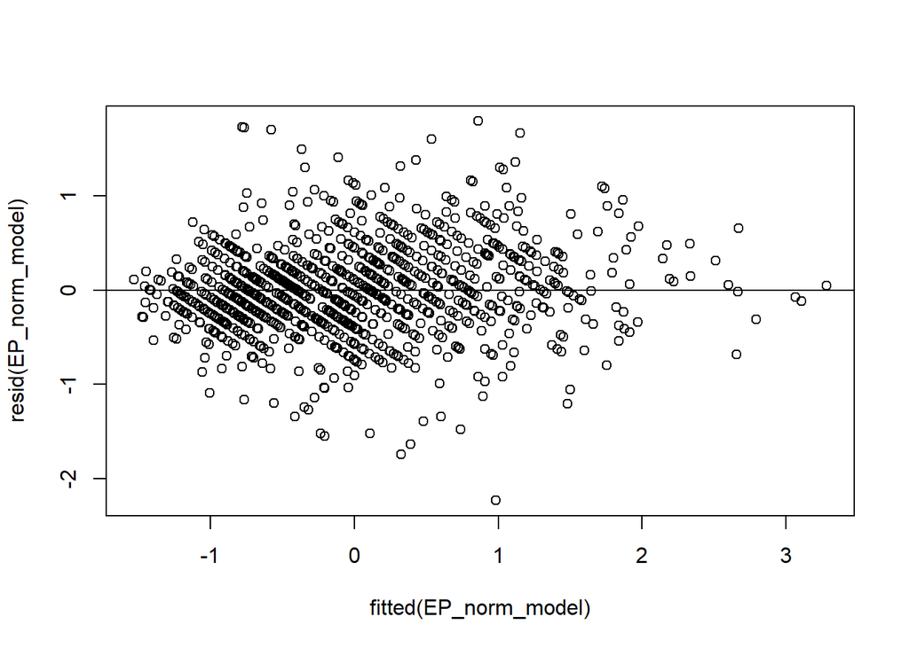

```r
# plot residuals against fitted values
plot(fitted(EP_norm_model), resid(EP_norm_model))
#add a horizontal line at 0
abline(0,0)
```

The x-axis displays the fitted values and the y-axis displays the residuals. From the plot we can see that the spread of the residuals tends to be slightly higher for fitted values in the mid-range, but it looks evenly spread overall.

#### 2.1.3 Q-Q plot

We can also produce a Q-Q plot, which is useful for determining if the residuals follow a normal distribution. If the data values in the plot fall along a roughly straight line at a 45-degree angle, then the data is normally distributed.

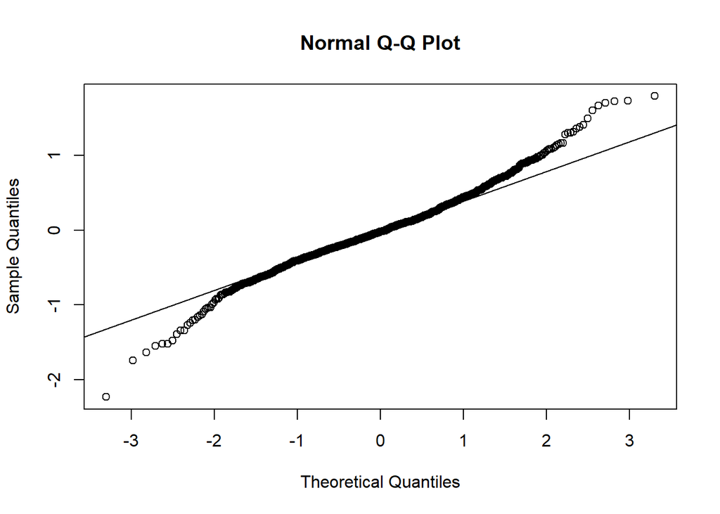

```r
#create Q-Q plot for residuals
qqnorm(resid(EP_norm_model))
#add a straight diagonal line to the plot
qqline(resid(EP_norm_model))
```

We can see that the residuals tend to stray from the line quite a bit near the tails, which indicates that they’re heavy tailed.

#### 2.1.4 density plot

We can also produce a density plot, which is also useful for visually checking whether or not the residuals are normally distributed. If the plot is roughly bell-shaped, then the residuals likely follow a normal distribution.

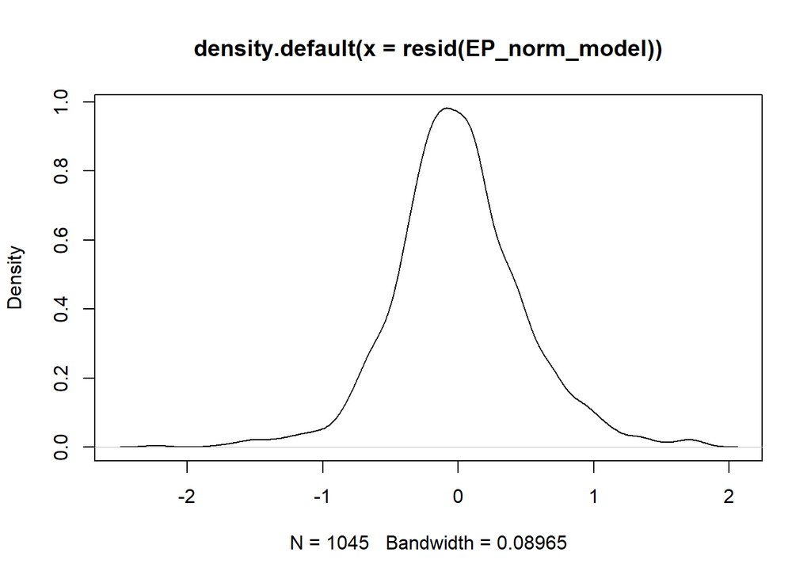

```r
#Create density plot of residuals
plot(density(resid(EP_norm_model)))
```

We can see that the density plot pretty closely follows a bell shape.

In sum:

```
  * Are there influential cases for your E-P line in the data?
```

*Some Cooks distance values are > 1, indicating the presence of overly influential datap oints for our E-P line*

```
  * Are the residuals normally distributed?
```

*The residuals are cloase to normally distributed (although the qq plot indicated heavy tails)*

```
  * Would you treat the sample for outliers?
```

*There may be a subset of higher values in the sample, but not a lot of evidence for significant outliers. We may thus explore whether outlier treatment improves the model fits (to ensure that the residuals are more normally distributed).*

If you do detect outliers in your sample that influence your model fit, there are three solutions:

1. Exclude outliers
2. Winsorize outliers
3. Fit E-P without outliers

### 2.2 Excluding outliers

If you are unsure whether the outliers identified in your sample may be due to erroneous responses, excluding them can be a good solution.

often, values > 3 standard deviations (SD) above or below the sample mean are considered outliers

```
  Task 2.2a: Define upper and lower boundry of P and E scores as sample mean + 3 SD.
```

```r
  P_upr = mean(ds$P, na.rm = T)+3*sd(ds$P, na.rm = T)
  P_lwr = mean(ds$P, na.rm = T)-3*sd(ds$P, na.rm = T)

  E_upr = mean(ds$E, na.rm = T)+3*sd(ds$E, na.rm = T)
  E_lwr = mean(ds$E, na.rm = T)-3*sd(ds$E, na.rm = T)
```

```
  Task 2.2b:
  *scale P and E values and save them as separate variables in the data frame. Identify measurements of at least 3 SDs above/below the sample mean.
  *create a new df in which you exclude all values that are at least 3 SDs above / below the sample mean.
  *re-fit the E-P line
  *check if there are still influential cases and compare to the previous model including outliers
```

```r
# first scale P and E values.

ds$scale_P <- scale(ds$P)
ds$scale_E <- scale(ds$E)

# Remember that "scaled_E" is the sum of scaled Ec and Eg values - which is not the same as scaling the raw summed scores
```

Exclude all data points at which subjects score 3 SD >= mean:

```r
# identify subjects with absolute values of =>3. For scaled data, this represents > 3 SD above/below the sample mean
excl_P <- which(abs(ds$scale_P)>=3)
excl_E <- which(abs(ds$scale_E)>=3)

ds_no_outlier <- ds[-c(excl_P, excl_E),]
```

Re-fit the E-P line.

```r
# Re-fit the E-P model from above and to the new dataframe save the model as an object

EP_norm_model_excl <- ds_no_outlier %>%
  group_by(subject.ID) %>%

    # specify a model with a random effect for each subject
  lme4::lmer(scale(P)~scale(E)+ (1+scale(E)|subject.ID),data=.)
```

```
## boundary (singular) fit: see help('isSingular')
```

```r
EP_norm_model_excl
```

```
## Linear mixed model fit by REML ['lmerMod']
## Formula: scale(P) ~ scale(E) + (1 + scale(E) | subject.ID)
##    Data: .
## REML criterion at convergence: 2126.312
## Random effects:
##  Groups     Name        Std.Dev. Corr
##  subject.ID (Intercept) 0.71577
##             scale(E)    0.07823  1.00
##  Residual               0.53569
## Number of obs: 1041, groups:  subject.ID, 200
## Fixed Effects:
## (Intercept)     scale(E)
##    0.008267     0.354318
## optimizer (nloptwrap) convergence code: 0 (OK) ; 0 optimizer warnings; 1 lme4 warnings
```

```r
# The summary of the model object should still give you a similar result as above
summary(EP_norm_model_excl)
```

```
## Linear mixed model fit by REML ['lmerMod']
## Formula: scale(P) ~ scale(E) + (1 + scale(E) | subject.ID)
##    Data: .
##
## REML criterion at convergence: 2126.3
##
## Scaled residuals:
##     Min      1Q  Median      3Q     Max
## -4.2671 -0.5254 -0.0403  0.4977  3.5046
##
## Random effects:
##  Groups     Name        Variance Std.Dev. Corr
##  subject.ID (Intercept) 0.51233  0.71577
##             scale(E)    0.00612  0.07823  1.00
##  Residual               0.28696  0.53569
## Number of obs: 1041, groups:  subject.ID, 200
##
## Fixed effects:
##             Estimate Std. Error t value
## (Intercept) 0.008267   0.053357   0.155
## scale(E)    0.354318   0.028752  12.323
##
## Correlation of Fixed Effects:
##          (Intr)
## scale(E) 0.207
## optimizer (nloptwrap) convergence code: 0 (OK)
## boundary (singular) fit: see help('isSingular')
```

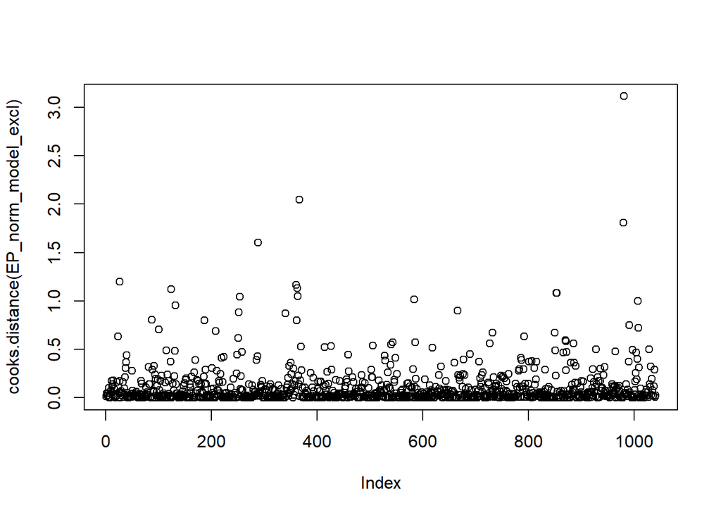

```r
# check for influential cases.
plot(cooks.distance(EP_norm_model_excl))
```

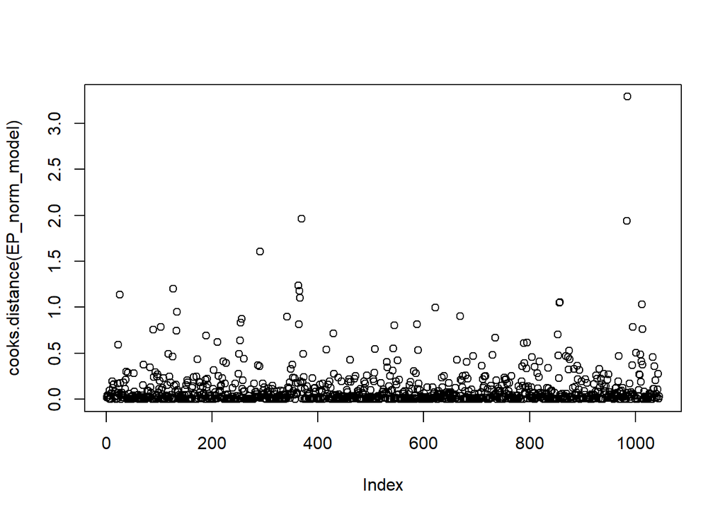

```r
# compare to the previous model
plot(cooks.distance(EP_norm_model))
```

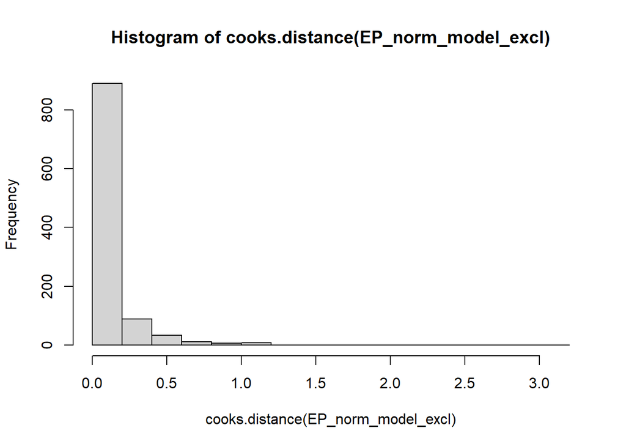

```r
# check for influential cases.
hist(cooks.distance(EP_norm_model_excl))
```

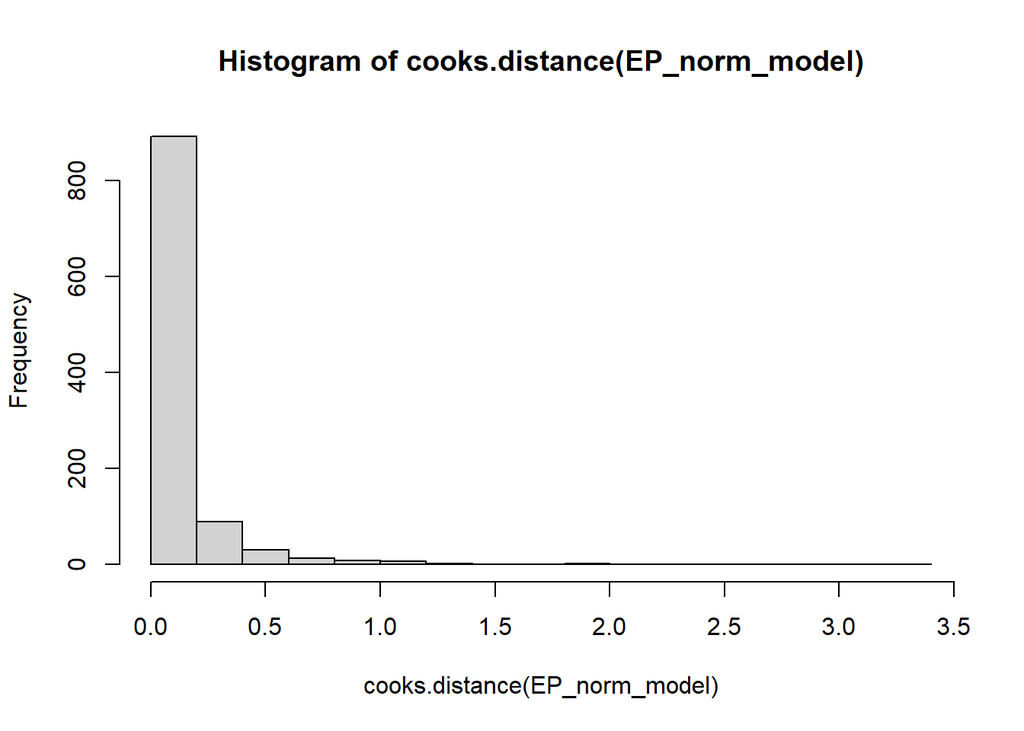

```r
# compare to the previous model
hist(cooks.distance(EP_norm_model))
```

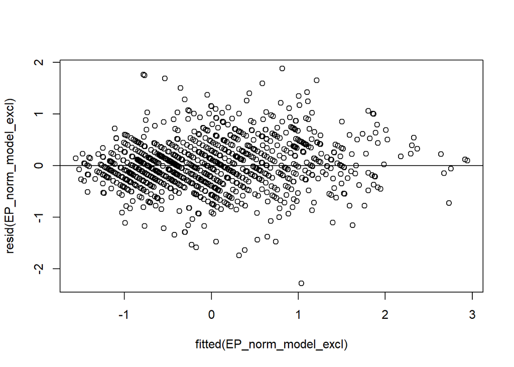

```r
# plot residuals against fitted values
plot(fitted(EP_norm_model_excl), resid(EP_norm_model_excl))
abline(0,0)
```

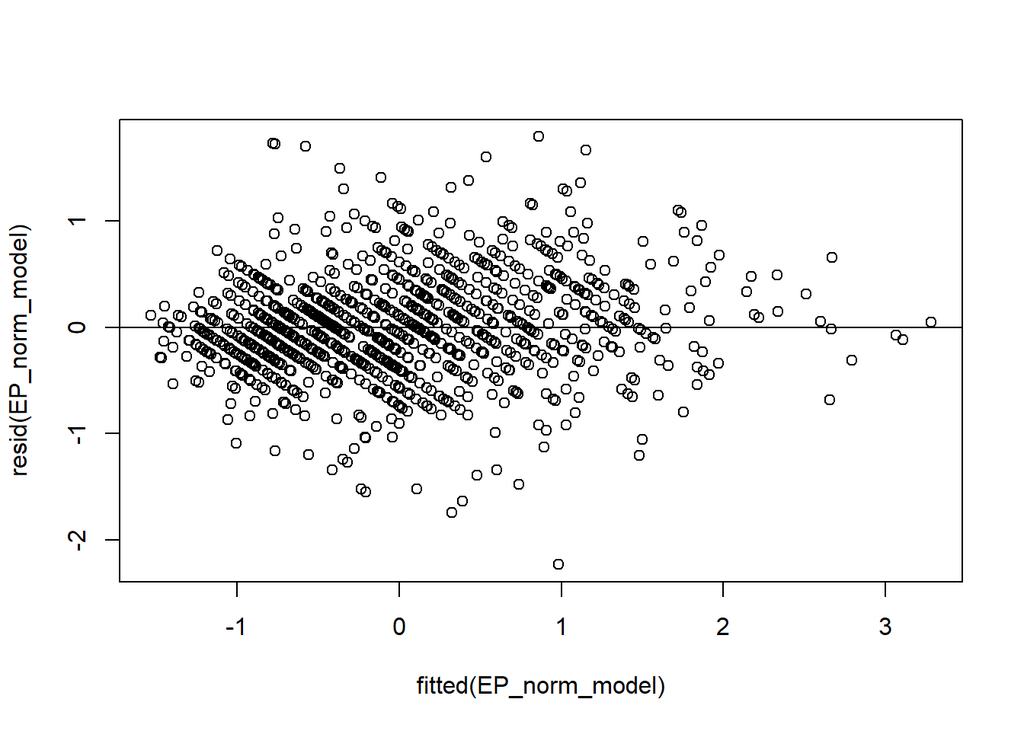

```r
# compare with old fit
plot(fitted(EP_norm_model), resid(EP_norm_model))
abline(0,0)
```

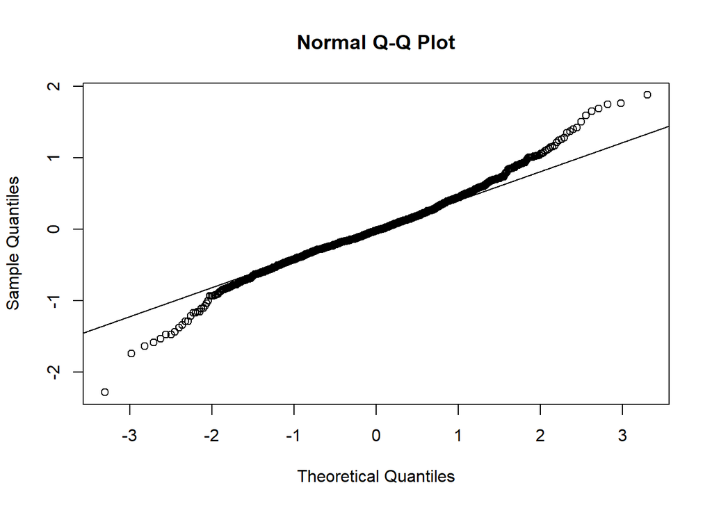

```r
#create Q-Q plot for residuals
qqnorm(resid(EP_norm_model_excl))
qqline(resid(EP_norm_model_excl))
```

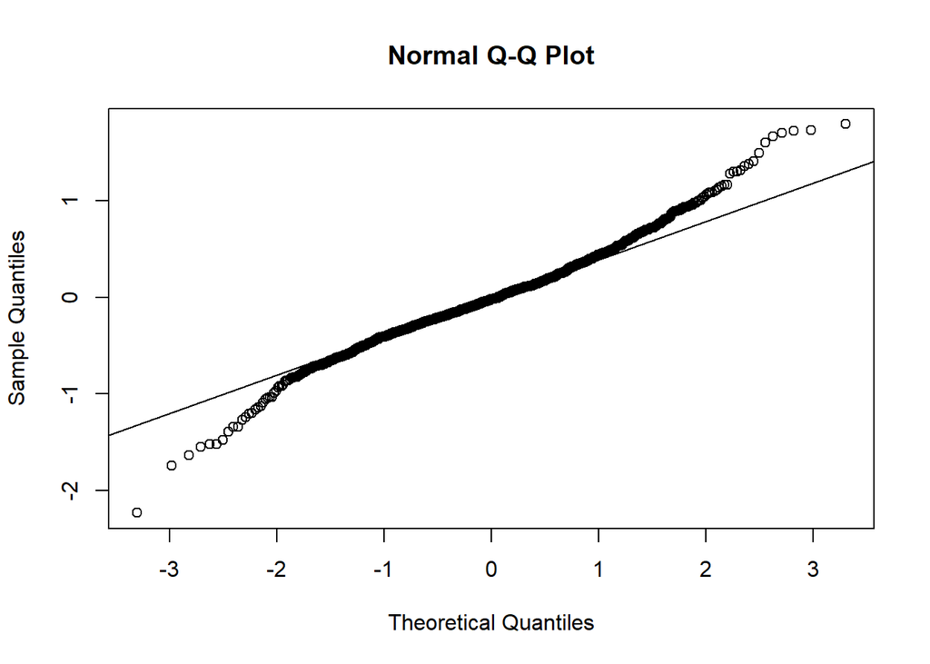

```r
# compare with old fit
qqnorm(resid(EP_norm_model))
qqline(resid(EP_norm_model))
```

Tip: you can also use the Mahalanobis distance to include mutidimensional outliers (i.e., outliers on multiple scales, here in E and P data) in one step

```r
# calculate sum of E-P scores and covariance
EP_data <- ds[,c("E","P")]
EP_mean <- colMeans(EP_data)
EP_cov <- cov(EP_data)

# Calculate mahalanobis distance
EP_md <- mahalanobis(EP_data, EP_mean, EP_cov)
EP_p <- pchisq(EP_md, df=1, lower.tail=FALSE)
ds$EP_md <- mahalanobis(EP_data, EP_mean, EP_cov)

# Calculate significance
ds$EP_p <- pchisq(EP_md, df=1, lower.tail=FALSE)

# Select all variables with significant distance
excl_MD <- which(ds$EP_p<=0.001)
ds_no_outlier <- ds[-excl_MD,]
```

### 2.3 Winsorizing Outliers

As mentioned above, we want to avoid excluding high P or E scores from our data (among many reasons: to i) avoid censoring the data, ii) use as much data as possible (for ethical and statistical reasons), and iii) because these may be particularly interesting for resilience and mental health research questions)

However, we still have to make sure that these outliers do not impair your model fit.

Assuming that there are no errors in the data, one way to maintain their information is to “winsorize” rather than exclude these data. This means replacing those values > 3 SD below/above the mean with exaclty the values *at* 3 SDs above / below the mean.

```
  Task 2.3a: Winsorize P and E data and save into new variables.
```

Tip: For our purposes here, you can just use the custom function “winsorize” (file Winsorize.r) provided source(“./progs/winsorize.r”) # function from LP to winsorize

```r
ds$P.w <- winsorize(ds$P)
```

```
## winsorized upr 2
## winsorized lwr 0
## [1] "successfully winsorized upr"
## [1] "nothing winsorized lwr"
```

```r
ds$E.w <- winsorize(ds$E)
```

```
## winsorized upr 2
## winsorized lwr 0
## [1] "successfully winsorized upr"
## [1] "nothing winsorized lwr"
```

```r
# check max values
max(ds$P)
```

```
## [1] 34
```

```r
max(ds$P.w)
```

```
## [1] 32.05575
```

```r
max(ds$E)
```

```
## [1] 109
```

```r
max(ds$E.w)
```

```
## [1] 105.4345
```

Winsorizing successfully replaced the max values Now, you can rerun the above E-P model with the winsorized scores.

```
 Task 2.3b: Re-run E-P model and re-check influential cases and distributions (see 2.1.1-4) with the winsorized scores.
  Interpret the result: Are the influential cases removed and residuals now normally distributed?
```

Refitting the E-P model

```r
# Re-fit the E-P model
EP_norm_model_winz <- ds %>%
  group_by(subject.ID) %>%

    # specify a model with a random effect for each subject
  lme4::lmer(scale(P.w)~scale(E.w)+ (1+scale(E)|subject.ID),data=.)
```

```
## boundary (singular) fit: see help('isSingular')
```

```r
EP_norm_model_winz
```

```
## Linear mixed model fit by REML ['lmerMod']
## Formula: scale(P.w) ~ scale(E.w) + (1 + scale(E) | subject.ID)
##    Data: .
## REML criterion at convergence: 2111.381
## Random effects:
##  Groups     Name        Std.Dev. Corr
##  subject.ID (Intercept) 0.7111
##             scale(E)    0.0845   1.00
##  Residual               0.5296
## Number of obs: 1045, groups:  subject.ID, 200
## Fixed Effects:
## (Intercept)   scale(E.w)
##    0.003968     0.358103
## optimizer (nloptwrap) convergence code: 0 (OK) ; 0 optimizer warnings; 1 lme4 warnings
```

```r
# The summary of the model object should still give you a similar result as above
summary(EP_norm_model_winz)
```

```
## Linear mixed model fit by REML ['lmerMod']
## Formula: scale(P.w) ~ scale(E.w) + (1 + scale(E) | subject.ID)
##    Data: .
##
## REML criterion at convergence: 2111.4
##
## Scaled residuals:
##     Min      1Q  Median      3Q     Max
## -4.2750 -0.5250 -0.0439  0.4920  3.4928
##
## Random effects:
##  Groups     Name        Variance Std.Dev. Corr
##  subject.ID (Intercept) 0.50573  0.7111
##             scale(E)    0.00714  0.0845   1.00
##  Residual               0.28048  0.5296
## Number of obs: 1045, groups:  subject.ID, 200
##
## Fixed effects:
##             Estimate Std. Error t value
## (Intercept) 0.003968   0.052979   0.075
## scale(E.w)  0.358103   0.028544  12.546
##
## Correlation of Fixed Effects:
##            (Intr)
## scale(E.w) 0.227
## optimizer (nloptwrap) convergence code: 0 (OK)
## boundary (singular) fit: see help('isSingular')
```

Checking distributions

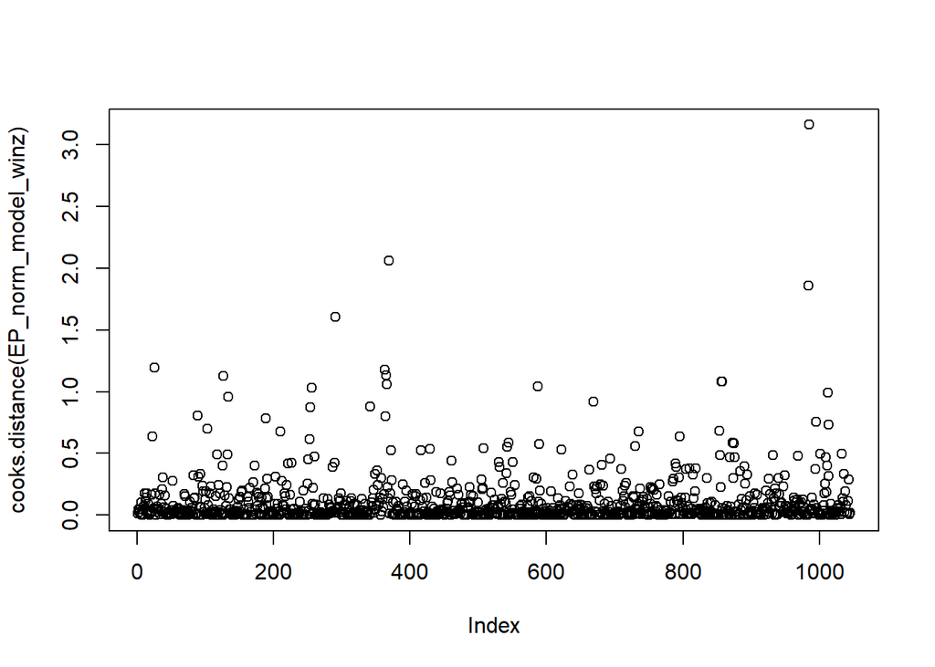

```r
# check for influential cases.
plot(cooks.distance(EP_norm_model_winz))
```

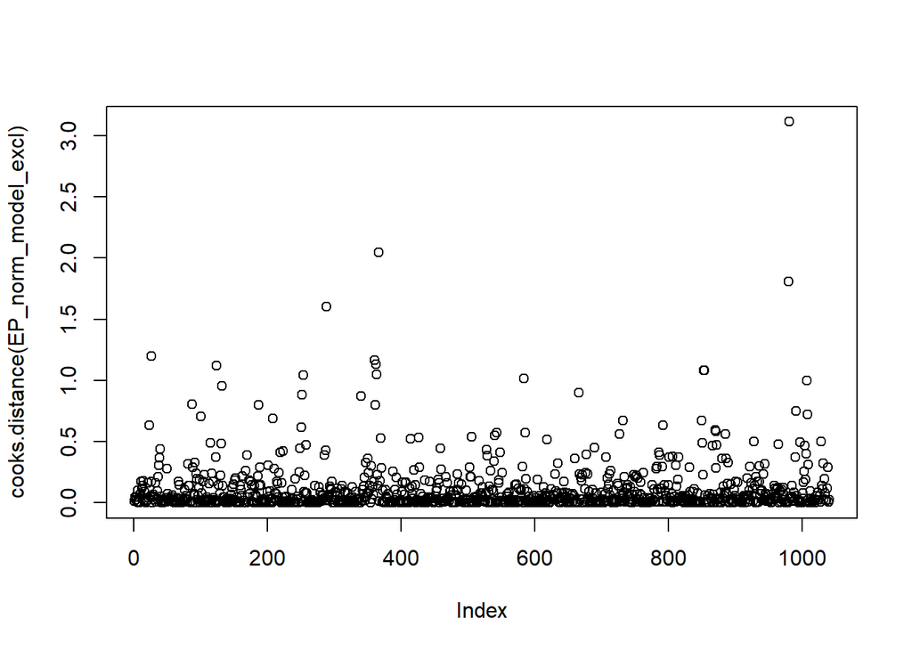

```r
# compare to the previous model
plot(cooks.distance(EP_norm_model_excl))
```